# **Arithmetic and Bitwise Operations**

#### **In this lesson we'll learn:**

1. Arithmetic Operations
2. Bitwise Operations

```python
# Our Setup, Import Libaries, Create our Imshow Function and Download our Images
import cv2
import numpy as np
from matplotlib import pyplot as plt

# Define our imshow function
def imshow(title = "Image", image = None, size = 10):
    w, h = image.shape[0], image.shape[1]
    aspect_ratio = w/h
    plt.figure(figsize=(size * aspect_ratio,size))
    plt.imshow(cv2.cvtColor(image, cv2.COLOR_BGR2RGB))
    plt.title(title)
    plt.show()

# # Download and unzip our images
# !wget https://moderncomputervision.s3.eu-west-2.amazonaws.com/images.zip
# !unzip -qq images.zip
```

# 1 **Arithmetic Operations**

Bu shunday operatsiyalarki tog'ridan tog'ri rang intensitysini ayirish yoki qo'shish imkonini beradi

Ikki massivning har bir element ishini hisoblaydi. Umumiy effekt yorqinlikni oshiradi yoki kamaytiradi

[figure not shown]

```
[[41 41 41 ...  5  5  5]
 [41 41 41 ...  5  5  5]
 [41 41 41 ...  5  5  5]
 ...
 [41 42 44 ... 34 33 32]
 [43 44 46 ... 31 30 28]
 [44 45 46 ... 32 30 29]]
```

```python
#imread funksiyasiga 0 ni argument sifatida berish directly rasmni grayscale ga o'tkazishdir
image = cv2.imread('Datasets/images/liberty.jpeg', 0)
imshow("Grayscaled Image",image)
print(image)

#1 lik image ni shape bn bir xil matrix yaratish va uni valuelarini 100 kopaytirish orqali tenglash
M = np.ones(shape=image.shape, dtype='uint8') * 100
```

```python
M
```

```
array([[100, 100, 100, ..., 100, 100, 100],
       [100, 100, 100, ..., 100, 100, 100],
       [100, 100, 100, ..., 100, 100, 100],
       ...,
       [100, 100, 100, ..., 100, 100, 100],
       [100, 100, 100, ..., 100, 100, 100],
       [100, 100, 100, ..., 100, 100, 100]], dtype=uint8)
```

## **Increasing Brightness**

[figure not shown]

[figure not shown]

```python
# M matrixni rasmga qo'shamiz.
# Brightness ni oshirish uchun
added = cv2.add(image, M)
imshow("Increasing Brightness", added) #shunning uchun Opencv dan add funksoyadidan foydalanish kerak.

# Agar shunchaki numpy orqali sonlarni qoshsak qanday bo'ladi.
#Rasm o'z xususiyatini buzib tashlaydi
added2 = image + M
imshow("Oddiy numpy bn intensitylarni qo'shish orqali", added2)
```

Ikkinchi rasm buzilishining sababi, rasmdagi ayrim pixellar intensitysi 200 bolishi mumkun va bunga 100 qo'shilgan, yangi rasmda o'sha pixel value 300 bo'lib keradi bunday rang value esa yo'q shu sababli **np 300-255=45** 300 yoki umuman 255 dan katta bo'lib ketgan qismlarni 0 ga tushirib hisoblab qoyadi. Misol: 300 bolgan pixellarni yangi rasmda 45 dagi qiymat bilan almashib ko'rinadi

## **Decreasing Brightness**

[figure not shown]

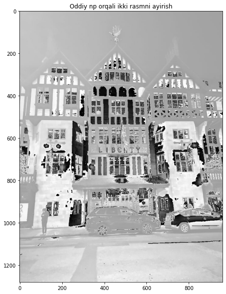

```python
#OpenCV da brightness tushirish operatori
subtracted = cv2.subtract(image, M)
imshow("Decreasing brightness", subtracted)

#Oddiy numpy orqali shuncaki ayirish bn yangi rasm paydo bolsa:
subtracted2 = image - M
imshow("Oddiy np orqali ikki rasmni ayirish", subtracted2)
#bunda ham yuqoridagidek muammo kuzatiladi.
```

# 2. **Bitwise Operations and Masking** - Masking qilishda juda foydali

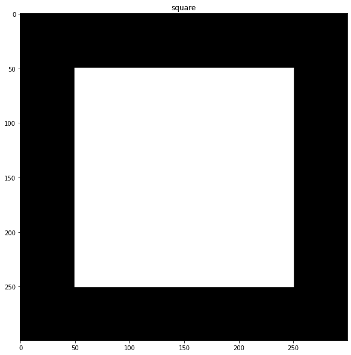

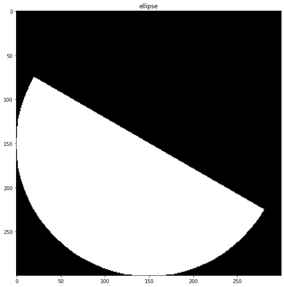

```python
# If you're wondering why only two dimensions, well this is a grayscale image,

# Making a square
square = np.zeros((300, 300), np.uint8)
cv2.rectangle(square, (50, 50), (250, 250), 255, -2)
imshow("square", square)

# Making a ellipse
ellipse = np.zeros((300, 300), np.uint8)
#img to draw, (centerx, centery), ()
cv2.ellipse(ellipse, (150, 150), (150, 150), 30, 0, 180, 255, -1)
imshow("ellipse", ellipse)
```

## **AND, OR, XOR and NOT**

LINK: https://pyimagesearch.com/2021/01/19/opencv-bitwise-and-or-xor-and-not/ AND: A bitwise AND is true if and only if both pixels are greater than zero. OR: A bitwise OR is true if either of the two pixels is greater than zero. XOR: A bitwise XOR is true if and only if one of the two pixels is greater than zero, but not both. NOT: A bitwise NOT inverts the “on” and “off” pixels in an image.

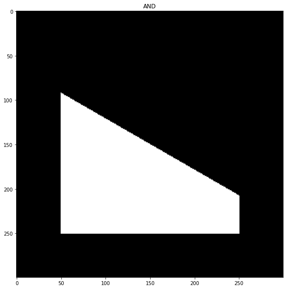

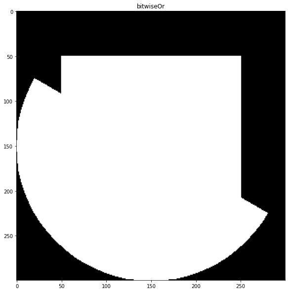

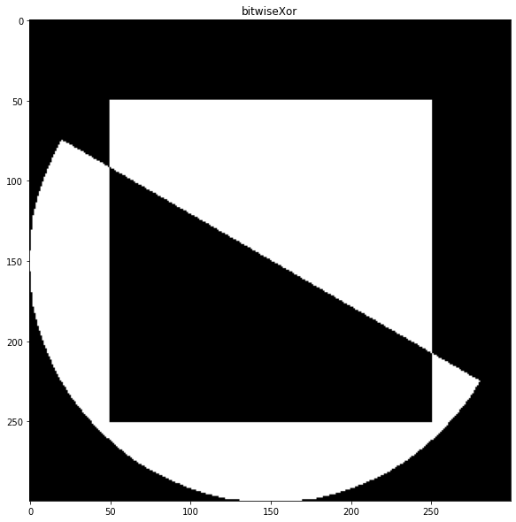

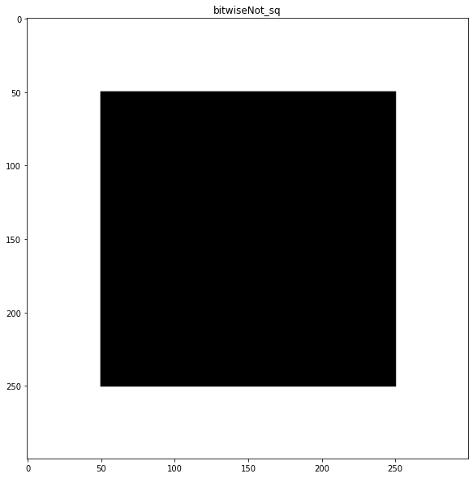

```python
# Faqatgina ikkalasi qo'shilgan joyni oladi. Kesishgan joyni
And = cv2.bitwise_and(square, ellipse)
imshow("AND", And)

# OR va ikkalasi ham mavjud qismni oladi
bitwiseOr = cv2.bitwise_or(square, ellipse)
imshow("bitwiseOr", bitwiseOr)

# Ikkalasining o'zi qaerda mavjudligini ko'rsatadi
bitwiseXor = cv2.bitwise_xor(square, ellipse)
imshow("bitwiseXor", bitwiseXor)

# Square dagi ranglarni invert qiladi. Yani va qorani rangdagi placelarni orinlarini almashtiradi
bitwiseNot_sq = cv2.bitwise_not(square)
imshow("bitwiseNot_sq", bitwiseNot_sq)

# Notice the last operation inverts the image totally
```